# Alexander H. von Hafften

Ph.D. Candidate in Economics and Finance at UW-Madison

[Home](https://vonhafften.github.io/index.html)

[Research](https://vonhafften.github.io/research.html)

[Teaching](https://vonhafften.github.io/teaching.html)

[CV](https://vonhafften.github.io/cv.pdf)

[LinkedIn](https://www.linkedin.com/in/alexander-h-von-hafften-9a48098b/)

[GitHub](https://github.com/vonhafften)

#### Highlighted Research

[Secondary-Market Capital Prices and Financial Frictions in Business Cycles](https://github.com/vonhafften/vonhafften.github.io/blob/main/research/jmp/paper.pdf) (Job Market Paper)

Secondary market capital prices are procyclical and volatile. This paper quantifies the role of financial frictions in amplifying secondary market capital price changes in response to aggregate productivity and credit shocks. To do so, I develop a quantitative industry equilibrium model of investment and capital reallocation with heterogeneous firms, endogenous entry and exit, and heterogeneous capital durability. I calibrate the model to match key moments in the dynamics of the universe of U.S. firms. Financially constrained firms are net buyers of less durable capital because of its lower upfront cost despite its lower future resale value. Financially constrained firms are more responsive to aggregate productivity and credit shocks than less financially constrained firms, so financial frictions amplify movements in secondary market capital prices. I decompose secondary market capital price volatility into 90 percent fundamental volatility and 10 percent amplification from financial frictions. When secondary market capital prices are held fixed, aggregate output volatility is 111 percent of the baseline. Allowing secondary market capital prices to follow frictionless dynamics attenuates output volatility by 8 percent and the remaining 3 percent stems from the amplified secondary market capital prices from financial frictions.

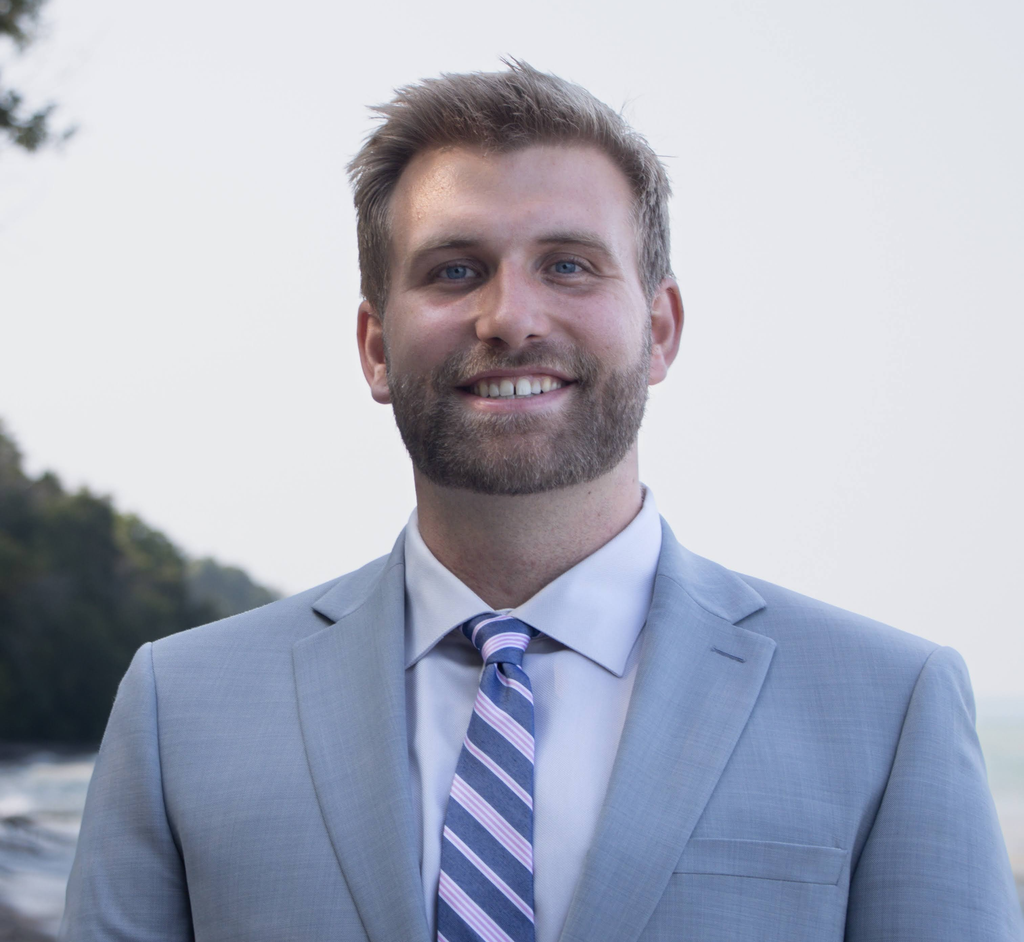